# STA380_Homework2

Charles Z. Aldrich

August 19, 2015

## Problem 1: Flights at ABIA

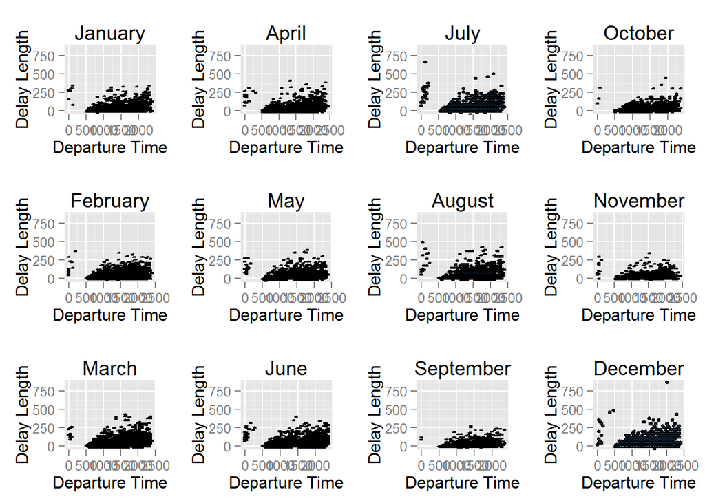

The resulting series of plots show the density in delay length throughout a 24 hr day. All plots are shown in the same scale in order to produce easy comparability across months. Insights from this plot include: the months to fly with the lowest delays throughout each day are September, October, and November. Additionally; June, July, August, and December show the longest delays by month. Finally, as expected, at the start of each day (5:00am), delays are near zero and climb uptil a relatively steady state is reached at rougouy 10:00am each day across each month. Therefore, if an individual wants to fly without having to deal with delays, they have a greater chance of doing so if using flights with departure times prior to 10:00am.

## Problem 3: Practice with Association Rule Mining

[output not shown]

After playing around with a variety of levels for support and confidence I elected to use the following: support = 0.001 and confidence = 0.05. The reason for the extremely small support level is that it provided results in which paired basket items in the lhs led to items in the rhs. With larger support levels there were only one to one relationships; no many to one relationships were present.

#### Readout with Lift > 5:

```
##    lhs                   rhs                   support confidence      lift
## 1  {popcorn}          => {salty snack}     0.001176778 0.25352113 10.424353
## 2  {liquor}           => {red/blush wine}  0.001111402 0.15596330 12.622300
## 3  {red/blush wine}   => {liquor}          0.001111402 0.08994709 12.622300
## 4  {liquor}           => {bottled beer}    0.002811192 0.39449541  7.618942
## 5  {bottled beer}     => {liquor}          0.002811192 0.05429293  7.618942
## 6  {condensed milk}   => {coffee}          0.001242155 0.18811881  5.039344
## 7  {salt}             => {sugar}           0.001111402 0.16037736  7.366763
## 8  {sugar}            => {salt}            0.001111402 0.05105105  7.366763
## 9  {herbs}            => {root vegetables} 0.003726464 0.35625000  5.083209
## 10 {root vegetables}  => {herbs}           0.003726464 0.05317164  5.083209
## 11 {baking powder}    => {sugar}           0.001634414 0.14367816  6.599703
## 12 {sugar}            => {baking powder}   0.001634414 0.07507508  6.599703
## 13 {flour}            => {sugar}           0.001895921 0.16959064  7.789965
## 14 {sugar}            => {flour}           0.001895921 0.08708709  7.789965
## 15 {liquor,
##     red/blush wine}   => {bottled beer}    0.001046025 0.94117647 18.177065
## 16 {bottled beer,
##     liquor}           => {red/blush wine}  0.001046025 0.37209302 30.113941
## 17 {bottled beer,
##     red/blush wine}   => {liquor}          0.001046025 0.41025641 57.571395
## 18 {other vegetables,
##     root vegetables}  => {herbs}           0.001438285 0.05670103  5.420619
## 19 {herbs,
##     whole milk}       => {root vegetables} 0.001176778 0.35294118  5.035996
## 20 {citrus fruit,
##     pip fruit}        => {tropical fruit}  0.003072699 0.37600000  5.572961
## 21 {citrus fruit,
##     tropical fruit}   => {pip fruit}       0.003072699 0.24607330  5.059055
```

After playing around with lift thresholds, I chose to go with > 5 because it returned 21 association rules that I felt made logical sense. For example, if a basket contains citrus fruit and pip fruit then it is likely to also contain tropical fruit. Another example is all combinations of liquor, red/blush wine, and bottled beer. A third example is condensed milk and coffee and a forth example is herbs and root vegetables. When I think of my own grocery shopping trips, these associations of items are things I could/would easily purchase together. They make logical sense.

#### Readout with Confidence > 0.4

```
##    lhs                   rhs                    support confidence      lift
## 1  {herbs}            => {other vegetables} 0.004314854  0.4125000  3.315607
## 2  {butter}           => {whole milk}       0.014382845  0.4036697  2.457036
## 3  {liquor,
##     red/blush wine}   => {bottled beer}     0.001046025  0.9411765 18.177065
## 4  {bottled beer,
##     red/blush wine}   => {liquor}           0.001046025  0.4102564 57.571395
## 5  {herbs,
##     whole milk}       => {other vegetables} 0.001372908  0.4117647  3.309697
## 6  {citrus fruit,
##     onions}           => {other vegetables} 0.001111402  0.4594595  3.693059
## 7  {onions,
##     whole milk}       => {other vegetables} 0.002288180  0.4268293  3.430783
## 8  {hamburger meat,
##     root vegetables}  => {other vegetables} 0.001307531  0.4255319  3.420355
## 9  {butter,
##     curd}             => {whole milk}       0.001242155  0.4318182  2.628369
## 10 {curd,
##     tropical fruit}   => {whole milk}       0.001503661  0.5227273  3.181710
## 11 {curd,
##     root vegetables}  => {whole milk}       0.001242155  0.4222222  2.569961
## 12 {curd,
##     other vegetables} => {whole milk}       0.003399582  0.4814815  2.930657
## 13 {butter,
##     root vegetables}  => {whole milk}       0.002092050  0.5161290  3.141548
## 14 {butter,
##     yogurt}           => {whole milk}       0.002615063  0.4210526  2.562842
## 15 {butter,
##     other vegetables} => {whole milk}       0.003791841  0.4603175  2.801837
## 16 {sausage,
##     soda}             => {rolls/buns}       0.002288180  0.4605263  3.893980
```

Similar to what was outlined above; after playing around with various levels for confidence I elected to use > 0.4 because it returned 16 association rules that again made logical sense to me. For example, one association rule was sausage, soda –> rolls/buns. This association rule could be indicative of an upcoming bbq or grill out. Additionally, this level of confidence also returned the association rule between beer, wine, and liquor.

Therefore, as noted by the example in the two pervious paragraphs, and by analyzing the association rules returned from each threshold, I believe the association rules generated in this problem make sense. Given a series of shopping baskets containing a variety of items, I believe that association rule mining found various relationships between basket purchases that make sense for a typical consumer. When looking at each assocation rule, I could see myself purchasing that series of items together on my next grocery trip.